# STATS 250 Lab 8

Lab Dream Team

Week of 10/19/2020

## Learning Objectives

### Statistical Learning Objectives

1. Discover the central limit theorem

### Functions covered in this lab

1. `replicate()`

### Weekly Advice

If the midterm did not go as well as you had hoped, that’s okay! There’s still plenty of time to make up the grade and to re-invest in the course. Your lab instructor is here to support you! Please reach out to them with questions or concerns.

**MAKE SURE YOU RUN THE `setup` CHUNK ON LINE 13**

## Lab Tutorial

This week, we’ll be exploring **sampling distributions**, which we’ve basically already seen: we’re now going to formalize the idea. A sampling distribution refers to the possible values for a *statistic* and how often those values occur. We’ve seen these already: the histograms of $\hat{p}_{\mathrm{sim}}$ we’ve used to find p-values are sampling distributions for $\hat{p}$.

Let’s take a look at the penguins data again.

```r
# Remember to set stringsAsFactors = TRUE!
penguins <- read.csv("https://raw.githubusercontent.com/STATS250SBI/palmerpenguins/master/inst/extdata/penguins_NArm.csv", stringsAsFactors = TRUE)
```

Let’s remind ourselves of what variables are in this data:

| Variable name | Description |
| --- | --- |
| `species` | Penguin species (Adélie, Chinstrap, and Gentoo) |
| `island` | Island in Palmer Archipeligo, Antarctica, on which the penguin was observed (Biscoe, Dream, or Torgersen) |
| `bill_length_mm` | A number denoting bill length (in millimeters) |
| `bill_depth_mm` | A number denoting bill depth (in millimeters) |
| `flipper_length_mm` | A whole number denoting flipper length (in millimeters) |
| `body_mass_g` | A whole number denoting penguin body mass (in grams) |
| `sex` | Penguin sex (female, male) |
| `year` | Study year (2007, 2008, 2009) |

```r
# Use your favorite function or two to explore the data
```

> IMPORTANT NOTE: For the purposes of this example, we’re going to assume that the penguins in the data represent the *population* of all penguins in the Palmer Archipelago. This is obviously not true: there are more than 333 penguins living on these islands. *This is just to illustrate ideas*. Keep that in mind.

Let’s say we want to estimate the proportion of Gentoo penguins in the Palmer Archipelago. Assuming our data represents the whole population of penguins, we know the right answer to this: about 36% of penguins are Gentoos. We’ll call this $p$, the population proportion of Gentoo penguins in the archipelago.

```r
# Pass a frequency table to the proportions() function to get proportions
proportions(table(penguins$species))
```

```
##
##    Adelie Chinstrap    Gentoo
## 0.4384384 0.2042042 0.3573574
```

Before we get started with random sampling, we’ll set the seed.

```r
set.seed(7923)
```

Generally, we can only take samples of populations. Let’s take a sample of size 20 from the “population” of all penguins:

```r
sample1 <- penguins[sample(1:333, size = 20), ]
```

We should unpack this code a bit. We’re creating a new `data.frame` called `sample1` that contains 20 randomly-sampled rows of `penguins`. We’re choosing those rows using the `sample()` function on the vector `1:333` – remember that there are 333 rows in the `penguins` data.frame. Once we’ve got our rows selected, we’re going to “select” those rows of `penguins` using square brackets.

Remember that data is **R**eally **C**ool, so we first tell R which **R**ows we want, then which **C**olumns. In `penguins[sample(1:333, size = 20), ]`, we’re telling R we want the sampled rows of `penguins`, then we type a comma to tell R which columns we want, and we leave that *blank*. Doing this tells R we want *all* the columns.

It’s easiest to see what we’ve just done by looking at it. We should see 20 rows and all the columns.

```r
sample1
```

```
##       species    island bill_length_mm bill_depth_mm flipper_length_mm
## 271 Chinstrap     Dream           45.2          17.8               198
## 252    Gentoo    Biscoe           43.3          14.0               208
## 180    Gentoo    Biscoe           49.1          14.8               220
## 53     Adelie    Biscoe           36.5          16.6               181
## 269 Chinstrap     Dream           45.4          18.7               188
## 77     Adelie Torgersen           36.7          18.8               187
## 105    Adelie    Biscoe           38.1          16.5               198
## 240    Gentoo    Biscoe           50.8          15.7               226
## 239    Gentoo    Biscoe           44.5          14.7               214
## 19     Adelie    Biscoe           38.2          18.1               185
## 20     Adelie    Biscoe           38.8          17.2               180
## 169    Gentoo    Biscoe           46.5          14.5               213
## 233    Gentoo    Biscoe           47.5          14.0               212
## 4      Adelie Torgersen           36.7          19.3               193
```

[output cut: 27 more lines]

Now, let’s see the proportion of Gentoo penguins in our sample ($\hat{p}$):

```r
proportions(table(sample1$species))
```

```
##
##    Adelie Chinstrap    Gentoo
##      0.50      0.15      0.35
```

In our sample, we have $\hat{p} = 0.35$: based on this sample, we estimate that 35% of penguins in the Palmer Archipelago are Gentoos. Now, we know that if we took a different sample of size 20, we’d get a different estimate of $p$ (a different $\hat{p}$). So let’s do it again!

```r
sample2 <- penguins[sample(1:333, size = 20), ] # reusing the same code as above
proportions(table(sample2$species))
```

```
##
##    Adelie Chinstrap    Gentoo
##      0.65      0.20      0.15
```

In this new sample, we got $\hat{p} = 0.15$. We can get a better sense of what’s going on by taking many samples of size 20: let’s take 1000 samples (no reason why 1000 in particular; it’s just a big number that’s not *too* big) using our old friend `replicate()`.

```r
samplesOfSize20 <- replicate(1000, {
  s <- penguins[sample(1:333, size = 20), ]
  proportions(table(s$species))["Gentoo"]
})
```

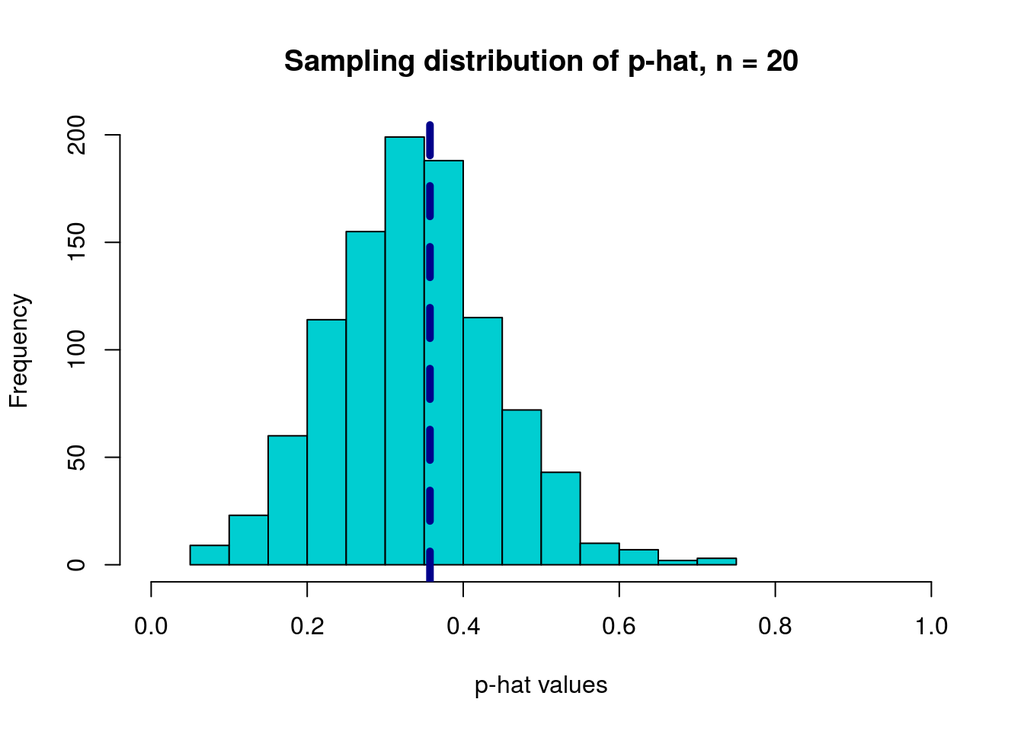

```r
hist(samplesOfSize20,
     main = "Sampling distribution of p-hat, n = 20",
     xlab = "p-hat values",
     col = "darkturquoise",
     xlim = c(0, 1))
# we'll now use abline to add a vertical line at p, the 'population' proportion
abline(v = proportions(table(penguins$species))["Gentoo"],
       lwd = 5, lty = "dashed", col = "darkblue")
```

What do you notice about this distribution?

> *Write what you notice about the distribution here*

Now let’s switch things up and take larger samples: let’s say $n = 40$.

```r
samplesOfSize40 <- replicate(1000, {
  s <- penguins[sample(1:333, size = 40), ]
  proportions(table(s$species))["Gentoo"]
})
```

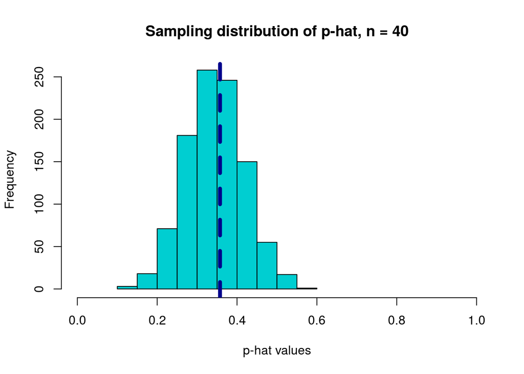

```r
hist(samplesOfSize40,
     main = "Sampling distribution of p-hat, n = 40",
     xlab = "p-hat values",
     col = "darkturquoise",
     xlim = c(0, 1))
# we'll now use abline to add a vertical line at p, the 'population' proportion
abline(v = proportions(table(penguins$species))["Gentoo"],
       lwd = 5, lty = "dashed", col = "darkblue")
```

How does this distribution compare to the `n = 20` distribution?

> *Replace this with your thoughts on the comparison*

Now let’s try increasing the sample size to 100.

```r
samplesOfSize100 <- replicate(1000, {
  s <- penguins[sample(1:333, size = 100), ]
  proportions(table(s$species))["Gentoo"]
})
```

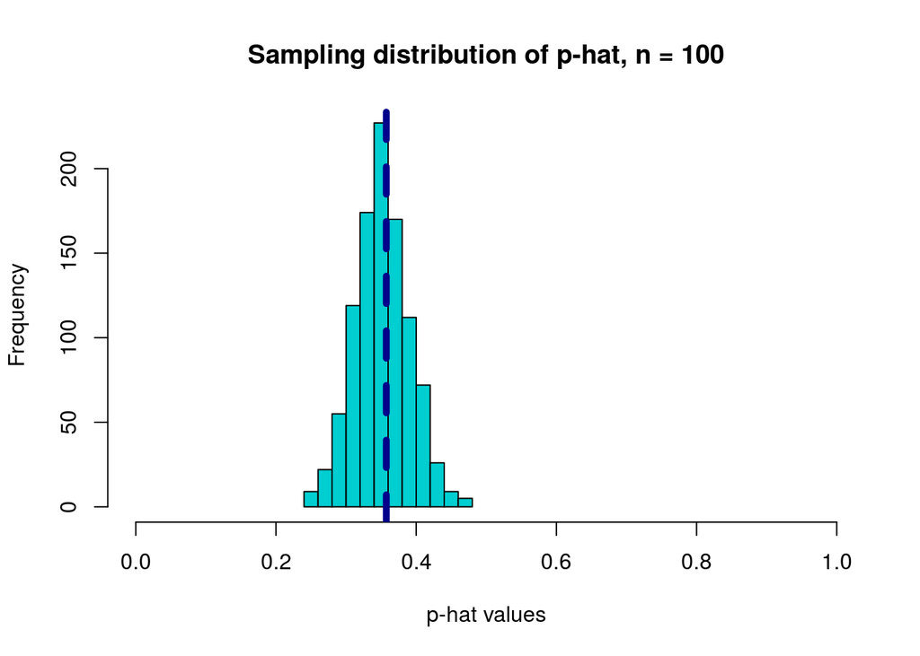

```r
hist(samplesOfSize100,
     main = "Sampling distribution of p-hat, n = 100",
     xlab = "p-hat values",
     col = "darkturquoise",
     xlim = c(0, 1))
# we'll now use abline to add a vertical line at p, the 'population' proportion
abline(v = proportions(table(penguins$species))["Gentoo"],
       lwd = 5, lty = "dashed", col = "darkblue")
```

Let’s stack the histograms on top of each other so we can see them better. Don’t worry about the code here as much as the visual.

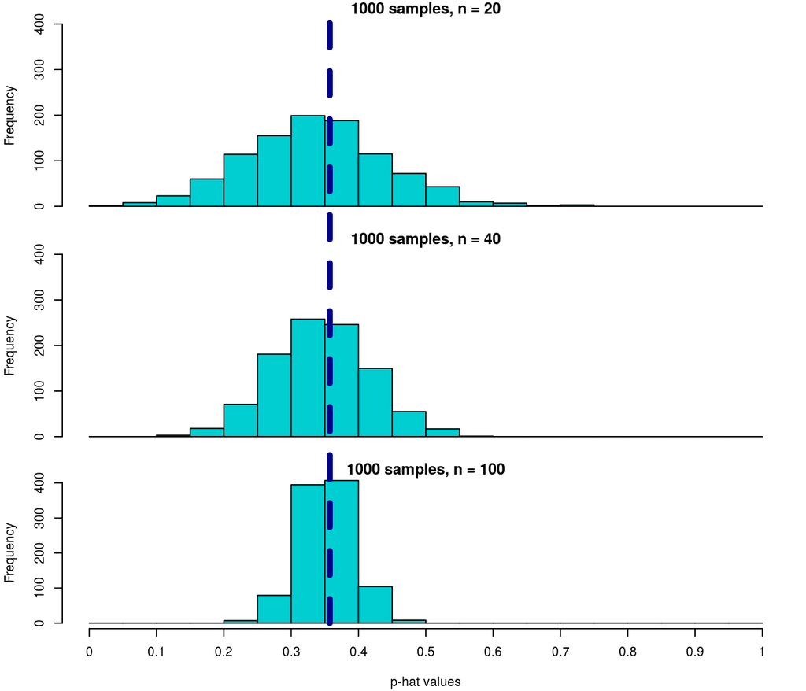

We should notice three things about these plots:

1. **Center:** (fill this in)
2. **Spread:** (fill this in)
3. **Shape:** (fill this in)

What we’re discovering here is called **the central limit theorem**:

> **Central Limit Theorem:** If we look at a proportion (or difference in proportions) and the scenario satisfies certain conditions, then the sample proportion (or difference in proportions) will appear to follow a bell-shaped curve called the *normal distribution*.

The two conditions we need to satisfy are: 1. **Observations in the sample are independent.** This is guaranteed if we have a random sample, or if we randomly divide individuals into treatment and control groups. 2. **The sample is large enough.** Here, “large enough” means $n\times p \geq 10$ and $n\times (1-p) \geq 10$, where $n$ is the sample size and $p$ is the *population proportion*. If we don’t have $p$, we can usually use $\hat{p}$ as a good estimate.

## Try It!

Depending on your instruction method (in person, synchronous remote, asynchronous remote), complete the following exercises collaboratively.

1. **In person:** Form groups of 2-4 with those around you (maintaining physical distance). Your instructor will provide additional details.
2. **Synchronous remote:** You will be placed in a Zoom breakout room to work together in small groups.
3. **Asynchronous remote:** Join a Piazza lab group for asynchronous collaboration.

**Collaborators:** If applicable, replace this text with the names of anyone you collaborated with on this project.

This week we will be working with data from the Stats 250 beginning of term student survey, specifically the question asking “Would you rather suddenly become CEO of a company or suddenly become a Senator?”

> **1.** Before the survey, the instructional team members thought that a majority of Stats 250 students would prefer to suddenly become a CEO (over suddenly becoming a Senator). Recall that in the survey, students only had two choices: CEO or Senator. Write the appropriate hypotheses below to test for whether a majority of Stats 250 students would prefer to suddenly become a CEO.
- $H_0$: replace this text with your null hypothesis
- $H_A$: replace this text with your alternative hypothesis

> **2.** The data can be found in ‘student_survey.csv’. Read in the data and call it ‘student_survey’.

```r
# Replace this comment with code required for Try It 3. (Remember that this text is a comment, so R ignores it; you can delete it if you want.) If you don't delete it, **start your code on a new line that doesn't start with #**
```

> **3.** This data set contains every student who took the survey in Stats 250. This is quite a large number, so we will instead grab a random sample of students from the data. Write the code that will grab a random sample of the size of your choice from the data. Why did you pick that size?

```r
# Replace this comment with code required for Try It 3. (Remember that this text is a comment, so R ignores it; you can delete it if you want.) If you don't delete it, **start your code on a new line that doesn't start with #**
```

Replace this text with your answer to Try It 3.

> **4.** We will use a total of 100 poker chips to simulate the null hypothesis model. Fill in the blanks: In order to conduct the simulation, a researcher decided that a blue poker chip represents ______(a)______ and a yellow poker chip represents ______(b)______. To perform the simulation, we will mix the blue and yellow poker chips, select ______(c)______ from the bag, and record the color before replacing the chip in the bag. The researcher will pick ______(d)______ times to complete the simulation. Then he counted how many ______(e)______ poker chips he has and divided by ______(f)______ to find the simulated proportion.

Replace this text with your answer to Try It 4.

> **5.** We would repeat the procedure above over and over until we reached 1000 simulations. Write the code that would do this action of 1000 simulations. Use this information to make a histogram of the simulated proportions. Then estimate the p-value and determine the conclusion of the hypothesis test.

```r
# Replace this comment with code required for Try It 5. (Remember that this text is a comment, so R ignores it; you can delete it if you want.) If you don't delete it, **start your code on a new line that doesn't start with #**
```

Replace this text with your answer to Try It 5.

> **6.** The instructional team also wonders if the answer to the “CEO or Senator” question differs between students who typically have jobs during the semester and those who don’t. Write the appropriate hypotheses below to test for whether there is a difference in proportions between students with jobs and without jobs who would prefer to suddenly become a CEO.
- $H_0$: replace this text with your null hypothesis
- $H_A$: replace this text with your alternative hypothesis

> **7.** Make a table of the sample data. Note that the `job` variable is coded so that “Yes” means “I typically have a job during the school year”. What is the observed difference in proportions?

```r
# Replace this comment with code required for Try It 7. (Remember that this text is a comment, so R ignores it; you can delete it if you want.) If you don't delete it, **start your code on a new line that doesn't start with #**
```

> **8.** In Try It 3, we found a random sample of a particular size from the data. We can use that same random sample to analyse our new hypotheses. Fill in the blanks: In order to conduct the simulation, a researcher wrote ______(a)______ on ______(b)______ index cards and ______(c)______ on ______(d)______ index cards to indicate whether or not a person ______(e)______. Then he shuffled the cards and dealt them into two groups of size ______(f)______ for ______(g)______ and size ______(h)______ for ______(i)______. He counted how many participants in each simulated group ______(j)______, and calculated the difference between the simulated proportions.

Replace this text with your answer to Try It 8.

> **9.** We would repeat the procedure above over and over until we reached 1000 simulations. Write the code that would do this action of 1000 simulations. Use this information to make a histogram of the simulated differences in proportions. Then estimate the p-value and determine the conclusion of the hypothesis test.

```r
# Replace this comment with code required for Try It 9. (Remember that this text is a comment, so R ignores it; you can delete it if you want.) If you don't delete it, **start your code on a new line that doesn't start with #**
```

## Dive Deeper

> **1.** Looking back to Try It 5, what is the mean of the histogram you made? Why do you think this value is the mean? Explain why you believe this is the case.

Replace this text with your written answer for Dive Deeper 1.

> **2.** Looking back to Try It 9, what is the mean of the histogram you made? Why do you think this value is the mean? Explain why you believe this is the case.

Replace this text with your written answer for Dive Deeper 2.

> **3.** Are the results generalizable to the general population of University of Michigan students? Why or why not?

Replace this text with your written answer to Dive Deeper 3.

## Wrap-Up and Submission

At the top of the document, make sure you’ve changed the `author` field to your name (in quotes!). If you’d like, change the date as well.

**When you’ve finished the lab, click the Knit button one last time.**

### Submission instructions

#### If you’re using RStudio Cloud

1. In the Files pane, check the box next to `lab07report.html`.
2. Click More > Export…
3. Click Download and save the file on your computer in a folder you’ll remember and be able to find later. You can just call the file `lab07report.html` or whatever else you’d like (as long as you remember what you called it).

#### If you’re using RStudio installed on your computer

1. locate the `lab06report.html` file on your computer. The file will be saved in the location indicated at the top of the files pane.